# 08 — Distance Premium and Floor Mechanisms

PGA Tour Distance & Speed Analytics

2026-07-07

# Overview

# 1. Setup

```r
# Core
library(tidyverse)
library(here)

# Utilities
library(broom)
library(scales)

source(here::here("config.R"))

set.seed(2025)

knitr::opts_chunk$set(
  echo    = TRUE,
  message = FALSE,
  warning = FALSE,
  fig.width  = 10,
  fig.height = 6
)
```

```r
df_main <- readRDS(here(PATH_PROCESSED, "df_main.rds")) %>% filter(player_name != "Patrick Sheehan")
df_speed <- df_main %>% filter(year >= SPEED_ERA_START)

cat("Rows:", nrow(df_main), " Speed-era rows:", nrow(df_speed), "\n")
```

```
## Rows: 4169  Speed-era rows: 3578
```

# 2. Is the Distance Premium Real, or a Proxy for Overall Skill?

Project 3 found the *raw* distance premium (`sg_total ~ dist_vs_field`) roughly tripled from 2004 to 2025. But that raw premium doesn’t control for anything else — if today’s long hitters are increasingly *also* good at approach play, scrambling, and putting (which Project 5’s MANOVA found they are), some of the raw premium’s apparent growth could reflect distance becoming a better *proxy* for all-around skill, not distance itself paying off more on its own. This section tests that directly by adding the other three SG components as controls and seeing whether the distance coefficient survives.

```r
premium_comparison <- df_main %>%
  group_by(year) %>%
  summarise(
    raw_premium       = coef(lm(sg_total ~ dist_vs_field))[["dist_vs_field"]] * 10,
    conditional_premium = coef(lm(sg_total ~ dist_vs_field + sg_apr + sg_arg + sg_putt))[["dist_vs_field"]] * 10,
    .groups = "drop"
  )

premium_comparison %>% print(n = 10)
```

```
## # A tibble: 22 x 3
##     year raw_premium conditional_premium
##    <int>       <dbl>               <dbl>
##  1  2004      0.0584               0.191
##  2  2005      0.151                0.166
##  3  2006      0.0697               0.218
##  4  2007      0.0353               0.212
##  5  2008      0.0482               0.232
##  6  2009      0.159                0.213
##  7  2010      0.133                0.290
##  8  2011      0.116                0.227
##  9  2012      0.240                0.265
## 10  2013      0.115                0.196
## # i 12 more rows
```

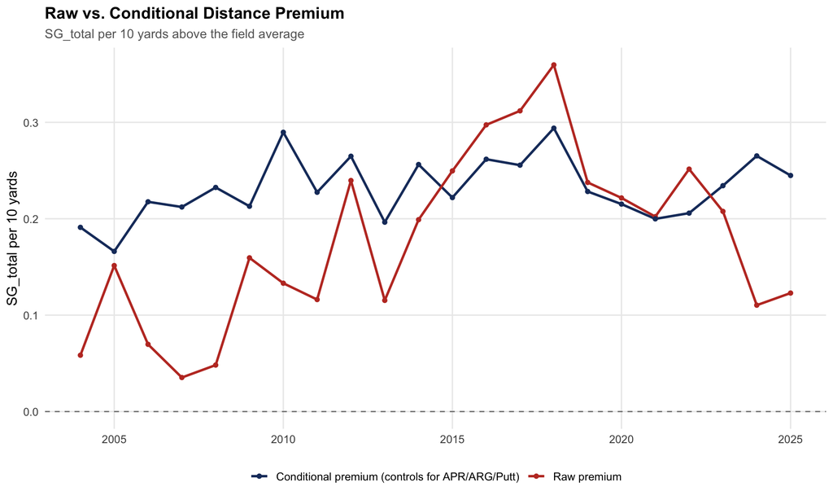

```r
premium_long <- premium_comparison %>%
  pivot_longer(-year, names_to = "type", values_to = "premium")

p_premium_comparison <- ggplot(premium_long, aes(year, premium, color = type)) +
  geom_line(linewidth = 1) +
  geom_point() +
  geom_hline(yintercept = 0, linetype = "dashed", color = "grey50") +
  scale_color_manual(
    values = c(raw_premium = COL_ACCENT, conditional_premium = COL_PRIMARY),
    labels = c(raw_premium = "Raw premium", conditional_premium = "Conditional premium (controls for APR/ARG/Putt)")
  ) +
  labs(
    title    = "Raw vs. Conditional Distance Premium",
    subtitle = "SG_total per 10 yards above the field average",
    x = NULL, y = "SG_total per 10 yards", color = NULL
  ) +
  THEME_BASE

p_premium_comparison
```

```r
corr_raw_cond <- cor(premium_comparison$raw_premium, premium_comparison$conditional_premium)
raw_2004 <- premium_comparison$raw_premium[premium_comparison$year == min(premium_comparison$year)]
cond_2004 <- premium_comparison$conditional_premium[premium_comparison$year == min(premium_comparison$year)]
raw_sd <- sd(premium_comparison$raw_premium)
cond_sd <- sd(premium_comparison$conditional_premium)
```

**Finding:** the two series correlate only 0.4 — they tell meaningfully different stories. In 2004, the raw premium was 0.06 but the conditional premium was already 0.19 — over 3x higher. And the conditional premium is far more *stable* across the whole window (SD = 0.032) than the raw premium (SD = 0.09), which visibly trends upward. **This means a meaningful part of the raw premium’s apparent growth reflects distance becoming a better proxy for overall skill** — today’s long hitters are increasingly also the accurate, good-short-game players (Project 5) — **not that a yard of distance, skill held constant, has become dramatically more valuable on its own.** The “pure” distance effect was already substantial in 2004 and has stayed roughly in the same range since.

## 2.1 Reference table

```r
premium_comparison %>%
  filter(year %in% c(2004, 2010, 2015, 2020, 2025)) %>%
  mutate(across(c(raw_premium, conditional_premium), ~round(.x, 2))) %>%
  print()
```

```
## # A tibble: 5 x 3
##    year raw_premium conditional_premium
##   <int>       <dbl>               <dbl>
## 1  2004        0.06                0.19
## 2  2010        0.13                0.29
## 3  2015        0.25                0.22
## 4  2020        0.22                0.22
## 5  2025        0.12                0.24
```

Project 3’s pooled mixed-effects model (§7) put the raw premium at ~0.12 (2004) rising to ~0.30 (2025) — roughly a 2.5x increase. This section adds the missing context: conditional on other skills, the increase is much smaller, because a large part of the raw trend is compositional (the kind of player who hits it long has changed), not purely mechanical (a yard of distance itself paying off more).

# 3. Setting Up the Compensation Question

Can a below-average-speed player still compete at an elite level by being excellent at the short game? And if so, has that gotten harder as the competitive floor has risen (Project 4)? Restricting to the speed era (`SPEED_ERA_START`+, since `ball_speed` isn’t reliable before 2007).

```r
df_bottom_speed <- df_speed %>%
  group_by(year) %>%
  mutate(speed_rank_pct = percent_rank(ball_speed), sg_rank = rank(-sg_total)) %>%
  ungroup() %>%
  filter(speed_rank_pct <= 0.25)

cat("Bottom-25%-ball-speed player-seasons:", nrow(df_bottom_speed), "\n")
```

```
## Bottom-25%-ball-speed player-seasons: 902
```

## 3.1 Does short game actually help this group?

```r
fit_compensation <- lm(sg_total ~ sg_putt + sg_apr, data = df_bottom_speed)
tidy(fit_compensation, conf.int = TRUE) %>% print()
```

```
## # A tibble: 3 x 7
##   term        estimate std.error statistic   p.value conf.low conf.high
##   <chr>          <dbl>     <dbl>     <dbl>     <dbl>    <dbl>     <dbl>
## 1 (Intercept)   -0.115    0.0114     -10.1 5.77e- 23   -0.138   -0.0931
## 2 sg_putt        0.940    0.0319      29.5 3.78e-134    0.878    1.00
## 3 sg_apr         1.31     0.0304      43.1 8.74e-221    1.25     1.37
```

**Finding:** among bottom-25%-speed players specifically, both `sg_putt` and `sg_apr` are strong, highly significant predictors of `sg_total` (coefficients both well above 0.9, p<0.001) — short-game and approach skill genuinely do help a below-average-speed player post a good overall season. The compensation mechanism is real, not wishful thinking.

## 3.2 Has it gotten harder to compensate all the way to elite status?

Real short-game skill helping *some* is different from it being enough to reach the *top* of the field. This tracks the share of bottom-25%-speed players each year who still make the top 50 in `sg_total`.

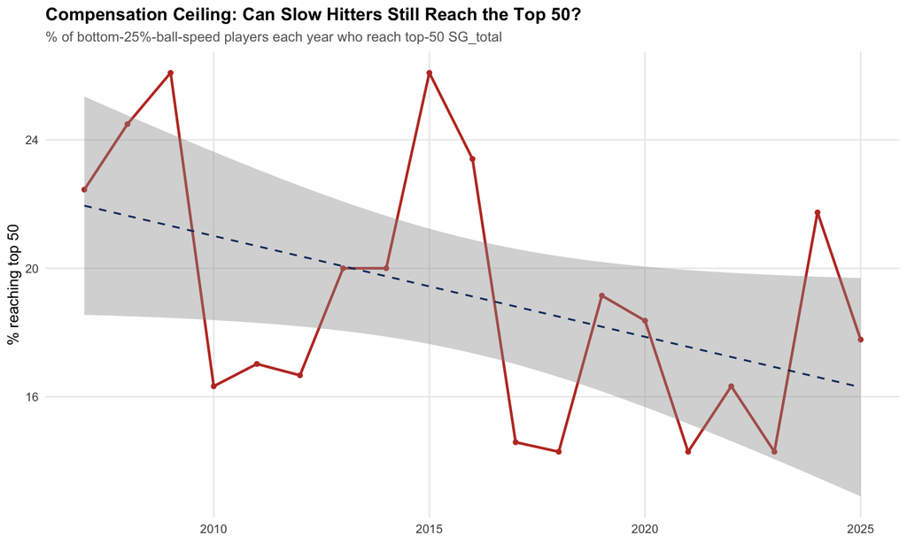

```r
compensation_ceiling <- df_bottom_speed %>%
  group_by(year) %>%
  summarise(n_slow = n(), pct_top50 = mean(sg_rank <= 50) * 100, .groups = "drop")

p_ceiling <- ggplot(compensation_ceiling, aes(year, pct_top50)) +
  geom_line(color = COL_ACCENT, linewidth = 1) +
  geom_point(color = COL_ACCENT) +
  geom_smooth(method = "lm", se = TRUE, color = COL_PRIMARY, linewidth = 0.7, linetype = "dashed") +
  labs(
    title    = "Compensation Ceiling: Can Slow Hitters Still Reach the Top 50?",
    subtitle = "% of bottom-25%-ball-speed players each year who reach top-50 SG_total",
    x = NULL, y = "% reaching top 50"
  ) +
  THEME_BASE

p_ceiling
```

```r
ceiling_trend <- tidy(lm(pct_top50 ~ year, data = compensation_ceiling)) %>% filter(term == "year")
early_ceiling <- compensation_ceiling %>% filter(year <= 2009) %>% summarise(m = mean(pct_top50)) %>% pull(m)
late_ceiling <- compensation_ceiling %>% filter(year >= 2020) %>% summarise(m = mean(pct_top50)) %>% pull(m)
```

**Finding:** the trend is negative (-0.314%/year) and **borderline significant** (p = 0.056) — worth stating plainly rather than rounding up to “significant” or dismissing as noise. The early-era average (2007-2009: 24.3%) is noticeably higher than the recent-era average (2020-2025: 17.1%). Read together with section 3.1: short-game compensation still genuinely works, but it’s gotten harder to compensate *all the way* to elite status as the overall floor has risen (Project 4) — consistent with, not contradicting, everything else this project has found about the rising floor.

# 4. Summary

- **The distance premium’s apparent 2.5x growth (Project 3) partly reflects distance becoming a better proxy for overall skill**, not a dramatic increase in distance’s own payoff — the conditional premium (controlling for other SG components) was already substantial in 2004 and has stayed comparatively stable since.
- **Short-game skill can genuinely help a below-average-speed player compete** — but the share who parlay that into a top-50 season has declined (borderline significant), consistent with a rising floor that’s outpacing what compensation alone can offset.